# Week 03 Day 02

Knowledge Check

## Announcements

- PS 03-04 due Saturday
- W03 D02 and W04 D01 Reading Annotations due Monday

## Knowlege Check

1. What formula do we use to compute the sample size needed for estimating $\mu$?

$$n \approx
\frac{z_{\alpha/2}s^2}{\epsilon^2}$$

2. What is the hardest part about using the above formula? Why?
3. Comment on what each symbol in the formula in #1 means and how you obtain values to plug in.
4. When estimating a mean, will increasing your level of confidence require more or less necessary sample size? Why?
5. When estimating a mean, will increasing your margin of error require more or less necessary sample size? Why?
6. What formula do you use to compute the sample size needed for estimating $p$?

$$n \approx
\frac{z_{\alpha/2}\hat{p}(1-\hat{p})}{\epsilon^2}$$

7. What is the hardest part about using the above formula? Why?
8. Comment on what each symbol in the formula in #6 means and how you obtain values to plug in.
9. Comment on how and why the formulas in #1 and #6 relate to one another.
10. When estimating $p$, what happens to the necessary sample size as $\hat{p}$ changes?
11. Small sample correction for finite populations:

$$\frac{N-n}{N-1}$$

$$SE(\hat{p}) =
\sqrt{\frac{\hat{p}(1-\hat{p})}{n}\frac{N-n}{n-1}}$$
This correction factor goes to 1 pretty quickly:

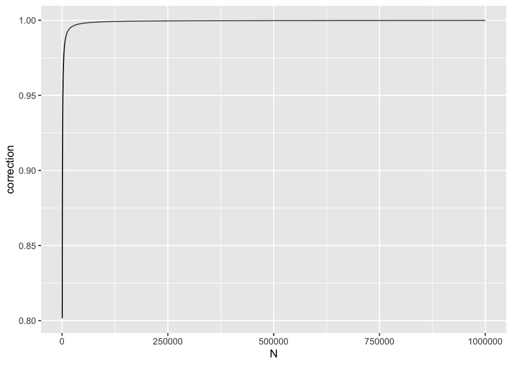

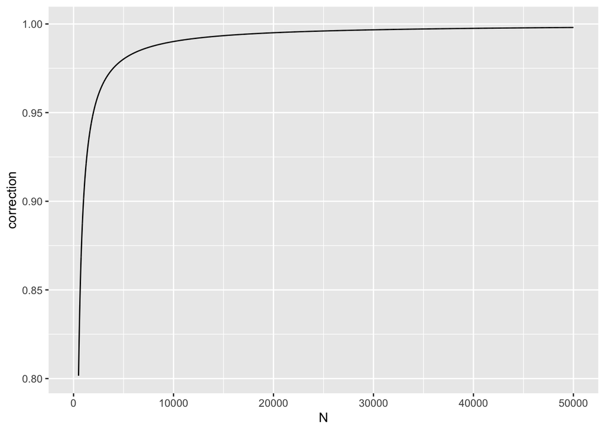